# Art Zaragoza_Neural_Networks_Customer_Churn_Project4_Full_code

```python
model_1.summary()
```

```
Model: "sequential"
```

```
┏━━━━━━━━━━━━━━━━━━━━━━━━━━━━━━━━━━━━━━┳━━━━━━━━━━━━━━━━━━━━━━━━━━━━━┳━━━━━━━━━━━━━━━━━┓
┃ Layer (type)                         ┃ Output Shape                ┃         Param # ┃
┡━━━━━━━━━━━━━━━━━━━━━━━━━━━━━━━━━━━━━━╇━━━━━━━━━━━━━━━━━━━━━━━━━━━━━╇━━━━━━━━━━━━━━━━━┩
│ dense (Dense)                        │ (None, 64)                  │             768 │
├──────────────────────────────────────┼─────────────────────────────┼─────────────────┤
│ dense_1 (Dense)                      │ (None, 32)                  │           2,080 │
├──────────────────────────────────────┼─────────────────────────────┼─────────────────┤
│ dense_2 (Dense)                      │ (None, 1)                   │              33 │
└──────────────────────────────────────┴─────────────────────────────┴─────────────────┘
```

```
 Total params: 2,881 (11.25 KB)
```

```
 Trainable params: 2,881 (11.25 KB)
```

```
 Non-trainable params: 0 (0.00 B)
```

More Drum rolls please ...

```python
# Fitting the ANN
print("\nFitting the Artificial Neural Network (ANN) Model: Adam Optimizer...\n")
history_1 = model_1.fit(
    X_train, y_train,
    batch_size=32,  # Specify the batch size to 32
    validation_data=(X_val, y_val),
    epochs=50,  # Specify the number of epochs to 50
    verbose=1
)
```

```
Fitting the Artificial Neural Network (ANN) Model: Adam Optimizer...

200/200 ━━━━━━━━━━━━━━━━━━━━ 3s 4ms/step - loss: 0.4976 - recall_1: 0.0810 - val_loss: 0.4180 - val_recall_1: 0.2638
200/200 ━━━━━━━━━━━━━━━━━━━━ 0s 2ms/step - loss: 0.3900 - recall_1: 0.3592 - val_loss: 0.3830 - val_recall_1: 0.3374
200/200 ━━━━━━━━━━━━━━━━━━━━ 0s 2ms/step - loss: 0.3597 - recall_1: 0.4182 - val_loss: 0.3689 - val_recall_1: 0.3804
200/200 ━━━━━━━━━━━━━━━━━━━━ 0s 2ms/step - loss: 0.3479 - recall_1: 0.4374 - val_loss: 0.3640 - val_recall_1: 0.3926
200/200 ━━━━━━━━━━━━━━━━━━━━ 0s 2ms/step - loss: 0.3422 - recall_1: 0.4499 - val_loss: 0.3612 - val_recall_1: 0.3926
200/200 ━━━━━━━━━━━━━━━━━━━━ 0s 2ms/step - loss: 0.3383 - recall_1: 0.4579 - val_loss: 0.3596 - val_recall_1: 0.3926
200/200 ━━━━━━━━━━━━━━━━━━━━ 0s 2ms/step - loss: 0.3353 - recall_1: 0.4607 - val_loss: 0.3583 - val_recall_1: 0.3926
200/200 ━━━━━━━━━━━━━━━━━━━━ 0s 2ms/step - loss: 0.3325 - recall_1: 0.4699 - val_loss: 0.3568 - val_recall_1: 0.4080
200/200 ━━━━━━━━━━━━━━━━━━━━ 0s 2ms/step - loss: 0.3300 - recall_1: 0.4753 - val_loss: 0.3560 - val_recall_1: 0.4080
200/200 ━━━━━━━━━━━━━━━━━━━━ 0s 2ms/step - loss: 0.3278 - recall_1: 0.4763 - val_loss: 0.3552 - val_recall_1: 0.4080
200/200 ━━━━━━━━━━━━━━━━━━━━ 0s 2ms/step - loss: 0.3257 - recall_1: 0.4802 - val_loss: 0.3549 - val_recall_1: 0.4080
200/200 ━━━━━━━━━━━━━━━━━━━━ 0s 2ms/step - loss: 0.3238 - recall_1: 0.4872 - val_loss: 0.3542 - val_recall_1: 0.4080
200/200 ━━━━━━━━━━━━━━━━━━━━ 0s 2ms/step - loss: 0.3220 - recall_1: 0.4905 - val_loss: 0.3540 - val_recall_1: 0.4080
200/200 ━━━━━━━━━━━━━━━━━━━━ 0s 2ms/step - loss: 0.3202 - recall_1: 0.4937 - val_loss: 0.3539 - val_recall_1: 0.4110
200/200 ━━━━━━━━━━━━━━━━━━━━ 0s 2ms/step - loss: 0.3185 - recall_1: 0.4942 - val_loss: 0.3538 - val_recall_1: 0.4172
200/200 ━━━━━━━━━━━━━━━━━━━━ 0s 2ms/step - loss: 0.3169 - recall_1: 0.4937 - val_loss: 0.3538 - val_recall_1: 0.4172
200/200 ━━━━━━━━━━━━━━━━━━━━ 0s 2ms/step - loss: 0.3153 - recall_1: 0.4964 - val_loss: 0.3542 - val_recall_1: 0.4172
200/200 ━━━━━━━━━━━━━━━━━━━━ 0s 2ms/step - loss: 0.3138 - recall_1: 0.4973 - val_loss: 0.3541 - val_recall_1: 0.4141
200/200 ━━━━━━━━━━━━━━━━━━━━ 0s 2ms/step - loss: 0.3124 - recall_1: 0.5001 - val_loss: 0.3544 - val_recall_1: 0.4141
200/200 ━━━━━━━━━━━━━━━━━━━━ 0s 2ms/step - loss: 0.3109 - recall_1: 0.5014 - val_loss: 0.3548 - val_recall_1: 0.4172
200/200 ━━━━━━━━━━━━━━━━━━━━ 0s 2ms/step - loss: 0.3094 - recall_1: 0.5014 - val_loss: 0.3552 - val_recall_1: 0.4202
200/200 ━━━━━━━━━━━━━━━━━━━━ 0s 2ms/step - loss: 0.3079 - recall_1: 0.5041 - val_loss: 0.3558 - val_recall_1: 0.4172
200/200 ━━━━━━━━━━━━━━━━━━━━ 0s 2ms/step - loss: 0.3068 - recall_1: 0.5073 - val_loss: 0.3563 - val_recall_1: 0.4202
200/200 ━━━━━━━━━━━━━━━━━━━━ 0s 2ms/step - loss: 0.3055 - recall_1: 0.5075 - val_loss: 0.3571 - val_recall_1: 0.4172
200/200 ━━━━━━━━━━━━━━━━━━━━ 0s 2ms/step - loss: 0.3043 - recall_1: 0.5082 - val_loss: 0.3578 - val_recall_1: 0.4202
200/200 ━━━━━━━━━━━━━━━━━━━━ 0s 2ms/step - loss: 0.3030 - recall_1: 0.5165 - val_loss: 0.3587 - val_recall_1: 0.4172
200/200 ━━━━━━━━━━━━━━━━━━━━ 0s 2ms/step - loss: 0.3017 - recall_1: 0.5191 - val_loss: 0.3596 - val_recall_1: 0.4080
200/200 ━━━━━━━━━━━━━━━━━━━━ 0s 2ms/step - loss: 0.3004 - recall_1: 0.5279 - val_loss: 0.3605 - val_recall_1: 0.4110
200/200 ━━━━━━━━━━━━━━━━━━━━ 0s 2ms/step - loss: 0.2991 - recall_1: 0.5384 - val_loss: 0.3616 - val_recall_1: 0.4110
200/200 ━━━━━━━━━━━━━━━━━━━━ 0s 2ms/step - loss: 0.2980 - recall_1: 0.5431 - val_loss: 0.3625 - val_recall_1: 0.4141
200/200 ━━━━━━━━━━━━━━━━━━━━ 0s 2ms/step - loss: 0.2968 - recall_1: 0.5447 - val_loss: 0.3635 - val_recall_1: 0.4141
200/200 ━━━━━━━━━━━━━━━━━━━━ 0s 2ms/step - loss: 0.2956 - recall_1: 0.5501 - val_loss: 0.3645 - val_recall_1: 0.4172
200/200 ━━━━━━━━━━━━━━━━━━━━ 0s 2ms/step - loss: 0.2946 - recall_1: 0.5508 - val_loss: 0.3655 - val_recall_1: 0.4172
200/200 ━━━━━━━━━━━━━━━━━━━━ 0s 2ms/step - loss: 0.2935 - recall_1: 0.5536 - val_loss: 0.3666 - val_recall_1: 0.4202
200/200 ━━━━━━━━━━━━━━━━━━━━ 0s 2ms/step - loss: 0.2924 - recall_1: 0.5611 - val_loss: 0.3676 - val_recall_1: 0.4202
200/200 ━━━━━━━━━━━━━━━━━━━━ 0s 2ms/step - loss: 0.2913 - recall_1: 0.5635 - val_loss: 0.3684 - val_recall_1: 0.4202
200/200 ━━━━━━━━━━━━━━━━━━━━ 0s 2ms/step - loss: 0.2903 - recall_1: 0.5675 - val_loss: 0.3694 - val_recall_1: 0.4202
200/200 ━━━━━━━━━━━━━━━━━━━━ 0s 2ms/step - loss: 0.2893 - recall_1: 0.5656 - val_loss: 0.3703 - val_recall_1: 0.4233
200/200 ━━━━━━━━━━━━━━━━━━━━ 0s 2ms/step - loss: 0.2882 - recall_1: 0.5674 - val_loss: 0.3713 - val_recall_1: 0.4233
200/200 ━━━━━━━━━━━━━━━━━━━━ 0s 2ms/step - loss: 0.2872 - recall_1: 0.5684 - val_loss: 0.3722 - val_recall_1: 0.4294
200/200 ━━━━━━━━━━━━━━━━━━━━ 0s 2ms/step - loss: 0.2862 - recall_1: 0.5701 - val_loss: 0.3731 - val_recall_1: 0.4325
200/200 ━━━━━━━━━━━━━━━━━━━━ 0s 2ms/step - loss: 0.2852 - recall_1: 0.5691 - val_loss: 0.3743 - val_recall_1: 0.4294
200/200 ━━━━━━━━━━━━━━━━━━━━ 0s 2ms/step - loss: 0.2842 - recall_1: 0.5712 - val_loss: 0.3754 - val_recall_1: 0.4325
200/200 ━━━━━━━━━━━━━━━━━━━━ 0s 2ms/step - loss: 0.2833 - recall_1: 0.5742 - val_loss: 0.3763 - val_recall_1: 0.4294
200/200 ━━━━━━━━━━━━━━━━━━━━ 0s 2ms/step - loss: 0.2821 - recall_1: 0.5767 - val_loss: 0.3773 - val_recall_1: 0.4325
200/200 ━━━━━━━━━━━━━━━━━━━━ 0s 2ms/step - loss: 0.2811 - recall_1: 0.5787 - val_loss: 0.3783 - val_recall_1: 0.4294
200/200 ━━━━━━━━━━━━━━━━━━━━ 0s 2ms/step - loss: 0.2803 - recall_1: 0.5785 - val_loss: 0.3793 - val_recall_1: 0.4294
200/200 ━━━━━━━━━━━━━━━━━━━━ 0s 2ms/step - loss: 0.2793 - recall_1: 0.5806 - val_loss: 0.3805 - val_recall_1: 0.4264
200/200 ━━━━━━━━━━━━━━━━━━━━ 0s 2ms/step - loss: 0.2784 - recall_1: 0.5798 - val_loss: 0.3813 - val_recall_1: 0.4325
200/200 ━━━━━━━━━━━━━━━━━━━━ 0s 2ms/step - loss: 0.2775 - recall_1: 0.5832 - val_loss: 0.3824 - val_recall_1: 0.4356
```

**History Keys in Keras Metrics**

```python
print(history_1.history.keys()) # Available keys in the history object for NN with Adam Optimizar:
```

[output not shown]

**Loss function**

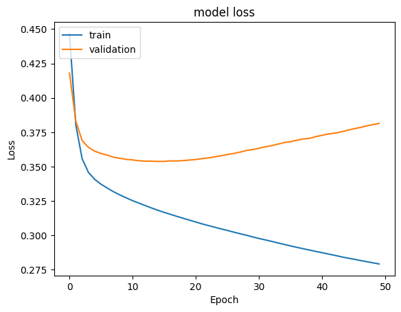

```python
#Plotting Train Loss vs Validation Loss
plt.plot(history_1.history['loss'])
plt.plot(history_1.history['val_loss'])
plt.title('Model #1 Loss - Adam Optimizer')
plt.ylabel('Loss')
plt.xlabel('Epoch')
plt.legend(['train', 'validation'], loc='upper left')
plt.show()
```

**Recall**

[figure not shown]

```python
#Plotting Train recall vs Validation recall (dict_keys(['loss', 'recall_1', 'val_loss', 'val_recall_1']))
plt.plot(history_1.history['recall_2'])
plt.plot(history_1.history['val_recall_2'])
plt.title('Model #1 Recall - Adam Optimizer')
plt.ylabel('Recall')
plt.xlabel('Epoch')
plt.legend(['train', 'validation'], loc='upper left')
plt.show()
```

```python
#Predicting the results using 0.5 as the threshold
y_train_pred = model_1.predict(X_train)
y_train_pred = (y_train_pred > 0.5)
y_train_pred
```

```
200/200 ━━━━━━━━━━━━━━━━━━━━ 0s 1ms/step
```

```
array([[False],
       [False],
       [False],
       ...,
       [False],
       [ True],
       [False]])
```

```python
model_name = "NN with Adam"

train_metric_df.loc[model_name] = recall_score(y_train,y_train_pred)
valid_metric_df.loc[model_name] = recall_score(y_val,y_val_pred)
```

**Classification report**

```python
#lassification report
cr=classification_report(y_train,y_train_pred)
print(cr)
```

```
              precision    recall  f1-score   support

           0       0.89      0.97      0.93      5096
           1       0.84      0.55      0.66      1304

    accuracy                           0.89      6400
   macro avg       0.86      0.76      0.80      6400
weighted avg       0.88      0.89      0.88      6400
```

```python
#lassification report
cr=classification_report(y_val,y_val_pred)
print(cr)
```

[output not shown]

**Confusion matrix**

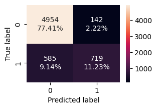

```python
#Calculating the confusion matrix
make_confusion_matrix(y_train, y_train_pred)
```

```python
#Calculating the confusion matrix
make_confusion_matrix(y_val, y_val_pred)
```

[output not shown]

Observations:

- Notice the increase of True Positives (TP) from Training set to validation set.
- Also notice the decrease of False Negatives (FN) from Training set to Validation set!

### (2) Neural Network with Adam Optimizer and Dropout - - Model Performance Improvement

Dropout is a regularization technique to prevent overfitting:

- Randomly “drops” neurons during training: At each training step, a random subset of neurons (and their connections) is “dropped” or temporarily deactivated. This forces the network to learn more robust patterns that don’t rely on specific neurons.
- Prevents overfitting: By randomly dropping neurons, the model cannot over-rely on any one feature or pattern, which helps it generalize better to unseen data, reducing overfitting.
- Improves performance: Dropout encourages the network to learn multiple independent features, improving overall model performance when deployed.

```python
backend.clear_session()
#Fixing the seed for random number generators so that we can ensure we receive the same output everytime
np.random.seed(2)
random.seed(2)
tf.random.set_seed(2)
```

```python
# Initializing the Neural Network with Adam Optimizer and Dropout
model_2 = Sequential()

# Adding the input layer with 32 neurons and relu as activation function
model_2.add(Dense(32, activation='relu', input_dim=X_train.shape[1]))

# Complete the code to add dropout with a ratio of 0.2
model_2.add(Dropout(0.2))

# Complete the code to add a hidden layer (specify the # of neurons and the activation function)
model_2.add(Dense(64, activation='relu'))  # Example: 64 neurons with relu activation

# Complete the code to add another hidden layer (specify the # of neurons and the activation function)
model_2.add(Dense(64, activation='relu'))  # Example: Another 64 neurons with relu activation

# Complete the code to add dropout with a ratio of 0.1
model_2.add(Dropout(0.1))

# Complete the code to add a hidden layer (specify the # of neurons and the activation function)
model_2.add(Dense(32, activation='relu'))  # Example: 32 neurons with relu activation

# Complete the code to add the number of neurons required in the output layer.
model_2.add(Dense(1, activation='sigmoid'))  # Example: 1 neuron for binary classification
```

```python
#Complete the code to use Adam as the optimizer.
optimizer = tf.keras.optimizers.Adam()

# uncomment one of the following lines to define the metric to be used
# metric = 'accuracy'
metric = keras.metrics.Recall()
# metric = keras.metrics.Precision()
# metric = keras.metrics.F1Score()
```

```python
# Complete the code to compile the model with binary cross entropy as loss function and recall as the metric.
model_2.compile(loss='binary_crossentropy', optimizer=optimizer, metrics=[metric])
```

```python
# Summary of the model
model_2.summary()
```

```
Model: "sequential"
```

```
┏━━━━━━━━━━━━━━━━━━━━━━━━━━━━━━━━━━━━━━┳━━━━━━━━━━━━━━━━━━━━━━━━━━━━━┳━━━━━━━━━━━━━━━━━┓
┃ Layer (type)                         ┃ Output Shape                ┃         Param # ┃
┡━━━━━━━━━━━━━━━━━━━━━━━━━━━━━━━━━━━━━━╇━━━━━━━━━━━━━━━━━━━━━━━━━━━━━╇━━━━━━━━━━━━━━━━━┩
│ dense (Dense)                        │ (None, 32)                  │             384 │
├──────────────────────────────────────┼─────────────────────────────┼─────────────────┤
│ dropout (Dropout)                    │ (None, 32)                  │               0 │
├──────────────────────────────────────┼─────────────────────────────┼─────────────────┤
│ dense_1 (Dense)                      │ (None, 64)                  │           2,112 │
├──────────────────────────────────────┼─────────────────────────────┼─────────────────┤
│ dense_2 (Dense)                      │ (None, 64)                  │           4,160 │
├──────────────────────────────────────┼─────────────────────────────┼─────────────────┤
│ dropout_1 (Dropout)                  │ (None, 64)                  │               0 │
├──────────────────────────────────────┼─────────────────────────────┼─────────────────┤
│ dense_3 (Dense)                      │ (None, 32)                  │           2,080 │
├──────────────────────────────────────┼─────────────────────────────┼─────────────────┤
│ dense_4 (Dense)                      │ (None, 1)                   │              33 │
└──────────────────────────────────────┴─────────────────────────────┴─────────────────┘
```

```
 Total params: 8,769 (34.25 KB)
```

```
 Trainable params: 8,769 (34.25 KB)
```

```
 Non-trainable params: 0 (0.00 B)
```

```python
# Fitting the ANN with batch_size = 32 and 100 epochs
history_2 = model_2.fit(
    X_train, y_train,
    batch_size=32,  # Specifying the batch size as 32
    epochs=100,  # Specifying the number of epochs as 100
    verbose=1,
    validation_data=(X_val, y_val)
)
```

```
200/200 ━━━━━━━━━━━━━━━━━━━━ 4s 5ms/step - loss: 0.5021 - recall: 0.0325 - val_loss: 0.4224 - val_recall: 0.1227
200/200 ━━━━━━━━━━━━━━━━━━━━ 0s 2ms/step - loss: 0.4207 - recall: 0.2949 - val_loss: 0.3781 - val_recall: 0.3129
200/200 ━━━━━━━━━━━━━━━━━━━━ 0s 2ms/step - loss: 0.3894 - recall: 0.3801 - val_loss: 0.3680 - val_recall: 0.3497
200/200 ━━━━━━━━━━━━━━━━━━━━ 0s 2ms/step - loss: 0.3774 - recall: 0.3914 - val_loss: 0.3653 - val_recall: 0.3558
200/200 ━━━━━━━━━━━━━━━━━━━━ 0s 2ms/step - loss: 0.3698 - recall: 0.4001 - val_loss: 0.3625 - val_recall: 0.3558
200/200 ━━━━━━━━━━━━━━━━━━━━ 0s 2ms/step - loss: 0.3622 - recall: 0.4099 - val_loss: 0.3605 - val_recall: 0.3834
200/200 ━━━━━━━━━━━━━━━━━━━━ 0s 2ms/step - loss: 0.3591 - recall: 0.4113 - val_loss: 0.3622 - val_recall: 0.3804
200/200 ━━━━━━━━━━━━━━━━━━━━ 0s 2ms/step - loss: 0.3610 - recall: 0.4424 - val_loss: 0.3590 - val_recall: 0.3896
200/200 ━━━━━━━━━━━━━━━━━━━━ 0s 2ms/step - loss: 0.3539 - recall: 0.4408 - val_loss: 0.3538 - val_recall: 0.4202
200/200 ━━━━━━━━━━━━━━━━━━━━ 0s 2ms/step - loss: 0.3498 - recall: 0.4324 - val_loss: 0.3543 - val_recall: 0.4049
200/200 ━━━━━━━━━━━━━━━━━━━━ 0s 2ms/step - loss: 0.3441 - recall: 0.4513 - val_loss: 0.3525 - val_recall: 0.4172
200/200 ━━━━━━━━━━━━━━━━━━━━ 0s 2ms/step - loss: 0.3520 - recall: 0.4514 - val_loss: 0.3534 - val_recall: 0.3988
200/200 ━━━━━━━━━━━━━━━━━━━━ 0s 2ms/step - loss: 0.3447 - recall: 0.4516 - val_loss: 0.3517 - val_recall: 0.3957
200/200 ━━━━━━━━━━━━━━━━━━━━ 0s 2ms/step - loss: 0.3435 - recall: 0.4510 - val_loss: 0.3503 - val_recall: 0.4387
200/200 ━━━━━━━━━━━━━━━━━━━━ 0s 2ms/step - loss: 0.3398 - recall: 0.4841 - val_loss: 0.3500 - val_recall: 0.4417
200/200 ━━━━━━━━━━━━━━━━━━━━ 0s 2ms/step - loss: 0.3376 - recall: 0.4700 - val_loss: 0.3534 - val_recall: 0.3865
200/200 ━━━━━━━━━━━━━━━━━━━━ 0s 2ms/step - loss: 0.3401 - recall: 0.4588 - val_loss: 0.3532 - val_recall: 0.4049
200/200 ━━━━━━━━━━━━━━━━━━━━ 0s 2ms/step - loss: 0.3369 - recall: 0.4872 - val_loss: 0.3508 - val_recall: 0.4049
200/200 ━━━━━━━━━━━━━━━━━━━━ 0s 2ms/step - loss: 0.3330 - recall: 0.4930 - val_loss: 0.3554 - val_recall: 0.4141
200/200 ━━━━━━━━━━━━━━━━━━━━ 0s 2ms/step - loss: 0.3424 - recall: 0.4717 - val_loss: 0.3507 - val_recall: 0.3957
200/200 ━━━━━━━━━━━━━━━━━━━━ 0s 2ms/step - loss: 0.3398 - recall: 0.4619 - val_loss: 0.3511 - val_recall: 0.4325
200/200 ━━━━━━━━━━━━━━━━━━━━ 0s 2ms/step - loss: 0.3278 - recall: 0.4908 - val_loss: 0.3548 - val_recall: 0.3957
200/200 ━━━━━━━━━━━━━━━━━━━━ 0s 2ms/step - loss: 0.3307 - recall: 0.4961 - val_loss: 0.3512 - val_recall: 0.3988
200/200 ━━━━━━━━━━━━━━━━━━━━ 0s 2ms/step - loss: 0.3262 - recall: 0.4995 - val_loss: 0.3516 - val_recall: 0.3957
200/200 ━━━━━━━━━━━━━━━━━━━━ 0s 2ms/step - loss: 0.3301 - recall: 0.4835 - val_loss: 0.3516 - val_recall: 0.4172
200/200 ━━━━━━━━━━━━━━━━━━━━ 0s 2ms/step - loss: 0.3273 - recall: 0.4920 - val_loss: 0.3525 - val_recall: 0.3957
200/200 ━━━━━━━━━━━━━━━━━━━━ 0s 2ms/step - loss: 0.3327 - recall: 0.4818 - val_loss: 0.3489 - val_recall: 0.4387
200/200 ━━━━━━━━━━━━━━━━━━━━ 0s 2ms/step - loss: 0.3263 - recall: 0.4824 - val_loss: 0.3509 - val_recall: 0.4141
200/200 ━━━━━━━━━━━━━━━━━━━━ 0s 2ms/step - loss: 0.3312 - recall: 0.4682 - val_loss: 0.3540 - val_recall: 0.4018
200/200 ━━━━━━━━━━━━━━━━━━━━ 0s 2ms/step - loss: 0.3272 - recall: 0.4827 - val_loss: 0.3501 - val_recall: 0.4264
200/200 ━━━━━━━━━━━━━━━━━━━━ 0s 2ms/step - loss: 0.3247 - recall: 0.4831 - val_loss: 0.3542 - val_recall: 0.4110
200/200 ━━━━━━━━━━━━━━━━━━━━ 0s 2ms/step - loss: 0.3266 - recall: 0.4856 - val_loss: 0.3533 - val_recall: 0.4080
200/200 ━━━━━━━━━━━━━━━━━━━━ 0s 2ms/step - loss: 0.3261 - recall: 0.4828 - val_loss: 0.3511 - val_recall: 0.4080
200/200 ━━━━━━━━━━━━━━━━━━━━ 0s 2ms/step - loss: 0.3276 - recall: 0.4856 - val_loss: 0.3518 - val_recall: 0.3988
200/200 ━━━━━━━━━━━━━━━━━━━━ 0s 2ms/step - loss: 0.3193 - recall: 0.5050 - val_loss: 0.3522 - val_recall: 0.4141
200/200 ━━━━━━━━━━━━━━━━━━━━ 0s 2ms/step - loss: 0.3233 - recall: 0.5064 - val_loss: 0.3526 - val_recall: 0.4049
200/200 ━━━━━━━━━━━━━━━━━━━━ 0s 2ms/step - loss: 0.3253 - recall: 0.4906 - val_loss: 0.3532 - val_recall: 0.3773
200/200 ━━━━━━━━━━━━━━━━━━━━ 0s 2ms/step - loss: 0.3210 - recall: 0.5106 - val_loss: 0.3523 - val_recall: 0.4356
200/200 ━━━━━━━━━━━━━━━━━━━━ 0s 2ms/step - loss: 0.3170 - recall: 0.5022 - val_loss: 0.3533 - val_recall: 0.4417
200/200 ━━━━━━━━━━━━━━━━━━━━ 0s 2ms/step - loss: 0.3230 - recall: 0.4781 - val_loss: 0.3502 - val_recall: 0.4325
```

[output cut: 45 more lines]

```
200/200 ━━━━━━━━━━━━━━━━━━━━ 0s 2ms/step - loss: 0.2947 - recall: 0.5577 - val_loss: 0.3734 - val_recall: 0.4141
200/200 ━━━━━━━━━━━━━━━━━━━━ 0s 2ms/step - loss: 0.2906 - recall: 0.5534 - val_loss: 0.3698 - val_recall: 0.4356
200/200 ━━━━━━━━━━━━━━━━━━━━ 0s 2ms/step - loss: 0.2945 - recall: 0.5465 - val_loss: 0.3713 - val_recall: 0.4571
200/200 ━━━━━━━━━━━━━━━━━━━━ 0s 2ms/step - loss: 0.2957 - recall: 0.5363 - val_loss: 0.3686 - val_recall: 0.4663
200/200 ━━━━━━━━━━━━━━━━━━━━ 0s 2ms/step - loss: 0.2882 - recall: 0.5625 - val_loss: 0.3752 - val_recall: 0.4601
200/200 ━━━━━━━━━━━━━━━━━━━━ 0s 2ms/step - loss: 0.2892 - recall: 0.5602 - val_loss: 0.3786 - val_recall: 0.4479
200/200 ━━━━━━━━━━━━━━━━━━━━ 0s 2ms/step - loss: 0.2841 - recall: 0.5752 - val_loss: 0.3802 - val_recall: 0.4448
200/200 ━━━━━━━━━━━━━━━━━━━━ 0s 2ms/step - loss: 0.2872 - recall: 0.5621 - val_loss: 0.3725 - val_recall: 0.4448
200/200 ━━━━━━━━━━━━━━━━━━━━ 0s 2ms/step - loss: 0.2913 - recall: 0.5773 - val_loss: 0.3746 - val_recall: 0.4908
200/200 ━━━━━━━━━━━━━━━━━━━━ 0s 2ms/step - loss: 0.2898 - recall: 0.5600 - val_loss: 0.3747 - val_recall: 0.4448
200/200 ━━━━━━━━━━━━━━━━━━━━ 0s 2ms/step - loss: 0.2884 - recall: 0.5410 - val_loss: 0.3771 - val_recall: 0.4509
200/200 ━━━━━━━━━━━━━━━━━━━━ 0s 2ms/step - loss: 0.2904 - recall: 0.5547 - val_loss: 0.3796 - val_recall: 0.4663
200/200 ━━━━━━━━━━━━━━━━━━━━ 0s 2ms/step - loss: 0.2877 - recall: 0.5522 - val_loss: 0.3782 - val_recall: 0.4387
200/200 ━━━━━━━━━━━━━━━━━━━━ 0s 2ms/step - loss: 0.2908 - recall: 0.5528 - val_loss: 0.3777 - val_recall: 0.4294
200/200 ━━━━━━━━━━━━━━━━━━━━ 0s 2ms/step - loss: 0.2874 - recall: 0.5413 - val_loss: 0.3850 - val_recall: 0.4417
```

```python
print(history_2.history.keys()) # Available keys in the history object for NN with Adam Optimizar:
```

```
dict_keys(['loss', 'recall', 'val_loss', 'val_recall'])
```

**Loss function**

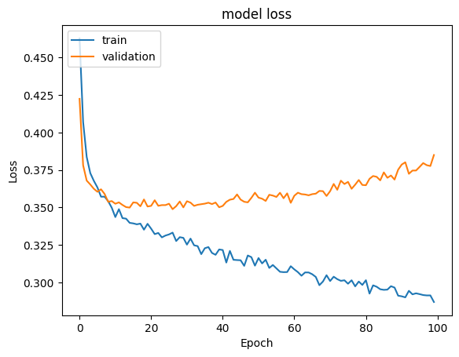

```python
#Plotting Train Loss vs Validation Loss
plt.plot(history_2.history['loss'])
plt.plot(history_2.history['val_loss'])
plt.title('Model #2 Loss - Adam Optimizer + Dropout')
plt.ylabel('Loss')
plt.xlabel('Epoch')
plt.legend(['train', 'validation'], loc='upper left')
plt.show()
```

Observations:

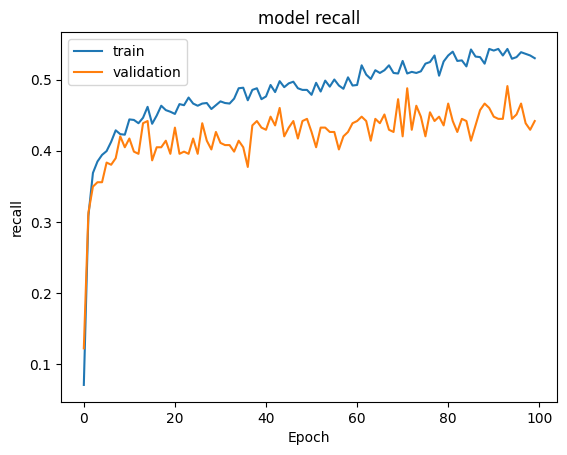

```python
#Plotting Train recall vs Validation recall
plt.plot(history_2.history['recall'])
plt.plot(history_2.history['val_recall'])
plt.title('Model #2 Recall - Adam Optimizer + Dropout')
plt.ylabel('Recall')
plt.xlabel('Epoch')
plt.legend(['train', 'validation'], loc='upper left')
plt.show()
```

Observations: The Recall metric for the validation dataset is slightly under the training set but generally follows the same curve/noise.

```python
#Predicting the results using best as a threshold
y_train_pred = model_2.predict(X_train)
y_train_pred = (y_train_pred > 0.5)
y_train_pred
```

```
200/200 ━━━━━━━━━━━━━━━━━━━━ 0s 1ms/step
```

```
array([[False],
       [False],
       [False],
       ...,
       [False],
       [ True],
       [False]])
```

```python
#Predicting the results using 0.5 as the threshold.
y_val_pred = model_2.predict(X_val)
y_val_pred = (y_val_pred > 0.5)
y_val_pred
```

```
50/50 ━━━━━━━━━━━━━━━━━━━━ 0s 1ms/step
```

```
array([[False],
       [False],
       [False],
       ...,
       [False],
       [ True],
       [ True]])
```

```python
model_name = "NN with Adam & Dropout"

train_metric_df.loc[model_name] = recall_score(y_train,y_train_pred)
valid_metric_df.loc[model_name] = recall_score(y_val,y_val_pred)
```

**Classification report**

```python
# Training set classification report
cr=classification_report(y_train,y_train_pred)
print(cr)
```

```
              precision    recall  f1-score   support

           0       0.91      0.97      0.94      5096
           1       0.85      0.61      0.71      1304

    accuracy                           0.90      6400
   macro avg       0.88      0.79      0.82      6400
weighted avg       0.89      0.90      0.89      6400
```

```python
# Predicting on the validation set
y_val_pred = model_2.predict(X_val)
y_val_pred = (y_val_pred > 0.5)  # Thresholding the predictions
```

```
50/50 ━━━━━━━━━━━━━━━━━━━━ 0s 1ms/step
```

```python
# Validation dataset classification report
from sklearn.metrics import classification_report
cr = classification_report(y_val, y_val_pred)  # y_val is the true labels, y_val_pred is the predicted labels
print(cr)
```

```
              precision    recall  f1-score   support

           0       0.87      0.95      0.91      1274
           1       0.68      0.44      0.54       326

    accuracy                           0.84      1600
   macro avg       0.77      0.69      0.72      1600
weighted avg       0.83      0.84      0.83      1600
```

**Confusion matrix**

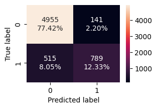

```python
#Calculating the confusion matrix
make_confusion_matrix(y_train, y_train_pred)
```

```python
#Calculating the confusion matrix
make_confusion_matrix(y_val, y_val_pred)
```

[output not shown]

Observations:

- Classification predictions on the training set loss and Recall improved.
- Confusion matrix indicate both Predicted False Negatives declined and True Positives increased.
- Recall = TP/(TP+FN)
- This was a nice exercise!!

### (3) Neural Network with Balanced Data (by applying SMOTE) and SGD Optimizer - - Model Performance Improvement

**Apply SMOTE to balance the dataset and then again apply hyperparamter tuning accordingly.**

```python
sm = SMOTE(random_state=42)
# Fitting SMOTE on the training data
X_train_smote, y_train_smote = sm.fit_resample(X_train, y_train)

# Printing the new shapes after upsampling
print('After UpSampling, the shape of X_train: {}'.format(X_train_smote.shape))
print('After UpSampling, the shape of y_train: {} \n'.format(y_train_smote.shape))
```

```
After UpSampling, the shape of X_train: (10192, 11)
After UpSampling, the shape of y_train: (10192,)
```

Let's build a model with the balanced dataset

```python
backend.clear_session()
#Fixing the seed for random number generators so that we can ensure we receive the same output everytime
np.random.seed(2)
random.seed(2)
tf.random.set_seed(2)
```

```python
# Initializing the model
model_3 = Sequential()

# Adding the input layer with 32 neurons and relu activation function
model_3.add(Dense(32, activation='relu', input_dim=X_train_smote.shape[1]))

# Adding a hidden layer with 16 neurons and relu activation function
model_3.add(Dense(16, activation='relu'))

# Adding a hidden layer with 8 neurons and relu activation function
model_3.add(Dense(8, activation='relu'))

# Adding the output layer with 1 neuron and sigmoid activation function for binary classification
model_3.add(Dense(1, activation='sigmoid'))
```

```python
#Complete the code to use SGD as the optimizer.
optimizer = tf.keras.optimizers.SGD(0.001)

# uncomment one of the following lines to define the metric to be used
# metric = 'accuracy'
metric = keras.metrics.Recall()
# metric = keras.metrics.Precision()
# metric = keras.metrics.F1Score()
```

```python
# Complete the code to compile the model with binary cross entropy as loss function and recall as the metric
model_3.compile(loss='binary_crossentropy', optimizer=optimizer, metrics=[metric])
```

```python
model_3.summary()
```

```
Model: "sequential"
```

```
┏━━━━━━━━━━━━━━━━━━━━━━━━━━━━━━━━━━━━━━┳━━━━━━━━━━━━━━━━━━━━━━━━━━━━━┳━━━━━━━━━━━━━━━━━┓
┃ Layer (type)                         ┃ Output Shape                ┃         Param # ┃
┡━━━━━━━━━━━━━━━━━━━━━━━━━━━━━━━━━━━━━━╇━━━━━━━━━━━━━━━━━━━━━━━━━━━━━╇━━━━━━━━━━━━━━━━━┩
│ dense (Dense)                        │ (None, 32)                  │             384 │
├──────────────────────────────────────┼─────────────────────────────┼─────────────────┤
│ dense_1 (Dense)                      │ (None, 16)                  │             528 │
├──────────────────────────────────────┼─────────────────────────────┼─────────────────┤
│ dense_2 (Dense)                      │ (None, 8)                   │             136 │
├──────────────────────────────────────┼─────────────────────────────┼─────────────────┤
│ dense_3 (Dense)                      │ (None, 1)                   │               9 │
└──────────────────────────────────────┴─────────────────────────────┴─────────────────┘
```

```
 Total params: 1,057 (4.13 KB)
```

```
 Trainable params: 1,057 (4.13 KB)
```

```
 Non-trainable params: 0 (0.00 B)
```

```python
# Fitting the ANN
history_3 = model_3.fit(
    X_train_smote,
    y_train_smote,
    batch_size=32,  # Specify the batch size, e.g., 32
    epochs=100,     # Specify the number of epochs, e.g., 100
    verbose=1,
    validation_data=(X_val, y_val)
)
```

```
319/319 ━━━━━━━━━━━━━━━━━━━━ 3s 6ms/step - loss: 0.6979 - recall: 0.8124 - val_loss: 0.7129 - val_recall: 0.8190
319/319 ━━━━━━━━━━━━━━━━━━━━ 1s 2ms/step - loss: 0.6953 - recall: 0.8224 - val_loss: 0.7083 - val_recall: 0.8129
319/319 ━━━━━━━━━━━━━━━━━━━━ 1s 2ms/step - loss: 0.6928 - recall: 0.8207 - val_loss: 0.7036 - val_recall: 0.7883
319/319 ━━━━━━━━━━━━━━━━━━━━ 1s 2ms/step - loss: 0.6903 - recall: 0.8077 - val_loss: 0.6989 - val_recall: 0.7577
319/319 ━━━━━━━━━━━━━━━━━━━━ 1s 2ms/step - loss: 0.6878 - recall: 0.7895 - val_loss: 0.6942 - val_recall: 0.7454
319/319 ━━━━━━━━━━━━━━━━━━━━ 1s 2ms/step - loss: 0.6852 - recall: 0.7692 - val_loss: 0.6895 - val_recall: 0.7209
319/319 ━━━━━━━━━━━━━━━━━━━━ 1s 2ms/step - loss: 0.6825 - recall: 0.7516 - val_loss: 0.6846 - val_recall: 0.6933
319/319 ━━━━━━━━━━━━━━━━━━━━ 1s 2ms/step - loss: 0.6797 - recall: 0.7333 - val_loss: 0.6800 - val_recall: 0.6810
319/319 ━━━━━━━━━━━━━━━━━━━━ 1s 2ms/step - loss: 0.6769 - recall: 0.7194 - val_loss: 0.6756 - val_recall: 0.6656
319/319 ━━━━━━━━━━━━━━━━━━━━ 1s 2ms/step - loss: 0.6741 - recall: 0.7128 - val_loss: 0.6715 - val_recall: 0.6595
319/319 ━━━━━━━━━━━━━━━━━━━━ 1s 2ms/step - loss: 0.6712 - recall: 0.7097 - val_loss: 0.6676 - val_recall: 0.6687
319/319 ━━━━━━━━━━━━━━━━━━━━ 1s 2ms/step - loss: 0.6684 - recall: 0.7073 - val_loss: 0.6639 - val_recall: 0.6595
319/319 ━━━━━━━━━━━━━━━━━━━━ 1s 2ms/step - loss: 0.6656 - recall: 0.7086 - val_loss: 0.6602 - val_recall: 0.6687
319/319 ━━━━━━━━━━━━━━━━━━━━ 1s 2ms/step - loss: 0.6626 - recall: 0.7136 - val_loss: 0.6567 - val_recall: 0.6595
319/319 ━━━━━━━━━━━━━━━━━━━━ 1s 2ms/step - loss: 0.6596 - recall: 0.7167 - val_loss: 0.6532 - val_recall: 0.6534
319/319 ━━━━━━━━━━━━━━━━━━━━ 1s 2ms/step - loss: 0.6565 - recall: 0.7178 - val_loss: 0.6498 - val_recall: 0.6564
319/319 ━━━━━━━━━━━━━━━━━━━━ 1s 2ms/step - loss: 0.6533 - recall: 0.7206 - val_loss: 0.6465 - val_recall: 0.6595
319/319 ━━━━━━━━━━━━━━━━━━━━ 1s 2ms/step - loss: 0.6501 - recall: 0.7231 - val_loss: 0.6431 - val_recall: 0.6595
319/319 ━━━━━━━━━━━━━━━━━━━━ 1s 2ms/step - loss: 0.6467 - recall: 0.7247 - val_loss: 0.6399 - val_recall: 0.6687
319/319 ━━━━━━━━━━━━━━━━━━━━ 1s 2ms/step - loss: 0.6433 - recall: 0.7286 - val_loss: 0.6368 - val_recall: 0.6748
319/319 ━━━━━━━━━━━━━━━━━━━━ 1s 2ms/step - loss: 0.6398 - recall: 0.7328 - val_loss: 0.6337 - val_recall: 0.6718
319/319 ━━━━━━━━━━━━━━━━━━━━ 1s 2ms/step - loss: 0.6363 - recall: 0.7363 - val_loss: 0.6308 - val_recall: 0.6779
319/319 ━━━━━━━━━━━━━━━━━━━━ 1s 2ms/step - loss: 0.6326 - recall: 0.7401 - val_loss: 0.6278 - val_recall: 0.6779
319/319 ━━━━━━━━━━━━━━━━━━━━ 1s 2ms/step - loss: 0.6290 - recall: 0.7446 - val_loss: 0.6249 - val_recall: 0.6810
319/319 ━━━━━━━━━━━━━━━━━━━━ 1s 2ms/step - loss: 0.6252 - recall: 0.7455 - val_loss: 0.6221 - val_recall: 0.6871
319/319 ━━━━━━━━━━━━━━━━━━━━ 1s 2ms/step - loss: 0.6215 - recall: 0.7495 - val_loss: 0.6194 - val_recall: 0.6902
319/319 ━━━━━━━━━━━━━━━━━━━━ 1s 2ms/step - loss: 0.6178 - recall: 0.7505 - val_loss: 0.6167 - val_recall: 0.6840
319/319 ━━━━━━━━━━━━━━━━━━━━ 1s 2ms/step - loss: 0.6140 - recall: 0.7529 - val_loss: 0.6140 - val_recall: 0.6902
319/319 ━━━━━━━━━━━━━━━━━━━━ 1s 2ms/step - loss: 0.6103 - recall: 0.7536 - val_loss: 0.6113 - val_recall: 0.6963
319/319 ━━━━━━━━━━━━━━━━━━━━ 1s 2ms/step - loss: 0.6066 - recall: 0.7538 - val_loss: 0.6088 - val_recall: 0.6994
319/319 ━━━━━━━━━━━━━━━━━━━━ 1s 2ms/step - loss: 0.6029 - recall: 0.7575 - val_loss: 0.6062 - val_recall: 0.6994
319/319 ━━━━━━━━━━━━━━━━━━━━ 1s 2ms/step - loss: 0.5993 - recall: 0.7595 - val_loss: 0.6038 - val_recall: 0.6963
319/319 ━━━━━━━━━━━━━━━━━━━━ 1s 2ms/step - loss: 0.5957 - recall: 0.7636 - val_loss: 0.6014 - val_recall: 0.6871
319/319 ━━━━━━━━━━━━━━━━━━━━ 1s 2ms/step - loss: 0.5922 - recall: 0.7646 - val_loss: 0.5990 - val_recall: 0.6902
319/319 ━━━━━━━━━━━━━━━━━━━━ 1s 2ms/step - loss: 0.5888 - recall: 0.7660 - val_loss: 0.5966 - val_recall: 0.6933
319/319 ━━━━━━━━━━━━━━━━━━━━ 1s 2ms/step - loss: 0.5855 - recall: 0.7651 - val_loss: 0.5942 - val_recall: 0.6933
319/319 ━━━━━━━━━━━━━━━━━━━━ 1s 2ms/step - loss: 0.5823 - recall: 0.7645 - val_loss: 0.5919 - val_recall: 0.6994
319/319 ━━━━━━━━━━━━━━━━━━━━ 1s 2ms/step - loss: 0.5792 - recall: 0.7641 - val_loss: 0.5896 - val_recall: 0.6994
319/319 ━━━━━━━━━━━━━━━━━━━━ 1s 2ms/step - loss: 0.5762 - recall: 0.7659 - val_loss: 0.5872 - val_recall: 0.6871
319/319 ━━━━━━━━━━━━━━━━━━━━ 1s 2ms/step - loss: 0.5733 - recall: 0.7629 - val_loss: 0.5848 - val_recall: 0.6871
```

[output cut: 45 more lines]

```
319/319 ━━━━━━━━━━━━━━━━━━━━ 1s 2ms/step - loss: 0.4877 - recall: 0.7798 - val_loss: 0.5105 - val_recall: 0.7607
319/319 ━━━━━━━━━━━━━━━━━━━━ 1s 2ms/step - loss: 0.4866 - recall: 0.7795 - val_loss: 0.5096 - val_recall: 0.7607
319/319 ━━━━━━━━━━━━━━━━━━━━ 1s 2ms/step - loss: 0.4855 - recall: 0.7793 - val_loss: 0.5086 - val_recall: 0.7577
319/319 ━━━━━━━━━━━━━━━━━━━━ 1s 2ms/step - loss: 0.4844 - recall: 0.7804 - val_loss: 0.5076 - val_recall: 0.7546
319/319 ━━━━━━━━━━━━━━━━━━━━ 1s 2ms/step - loss: 0.4833 - recall: 0.7814 - val_loss: 0.5065 - val_recall: 0.7546
319/319 ━━━━━━━━━━━━━━━━━━━━ 1s 2ms/step - loss: 0.4822 - recall: 0.7827 - val_loss: 0.5055 - val_recall: 0.7577
319/319 ━━━━━━━━━━━━━━━━━━━━ 1s 2ms/step - loss: 0.4812 - recall: 0.7830 - val_loss: 0.5046 - val_recall: 0.7577
319/319 ━━━━━━━━━━━━━━━━━━━━ 1s 2ms/step - loss: 0.4802 - recall: 0.7824 - val_loss: 0.5037 - val_recall: 0.7577
319/319 ━━━━━━━━━━━━━━━━━━━━ 1s 2ms/step - loss: 0.4792 - recall: 0.7827 - val_loss: 0.5026 - val_recall: 0.7546
319/319 ━━━━━━━━━━━━━━━━━━━━ 1s 2ms/step - loss: 0.4782 - recall: 0.7835 - val_loss: 0.5017 - val_recall: 0.7577
319/319 ━━━━━━━━━━━━━━━━━━━━ 1s 2ms/step - loss: 0.4772 - recall: 0.7835 - val_loss: 0.5007 - val_recall: 0.7577
319/319 ━━━━━━━━━━━━━━━━━━━━ 1s 2ms/step - loss: 0.4763 - recall: 0.7831 - val_loss: 0.4997 - val_recall: 0.7577
319/319 ━━━━━━━━━━━━━━━━━━━━ 1s 2ms/step - loss: 0.4754 - recall: 0.7828 - val_loss: 0.4988 - val_recall: 0.7577
319/319 ━━━━━━━━━━━━━━━━━━━━ 1s 2ms/step - loss: 0.4745 - recall: 0.7839 - val_loss: 0.4979 - val_recall: 0.7607
319/319 ━━━━━━━━━━━━━━━━━━━━ 1s 2ms/step - loss: 0.4736 - recall: 0.7841 - val_loss: 0.4970 - val_recall: 0.7638
```

**Loss function**

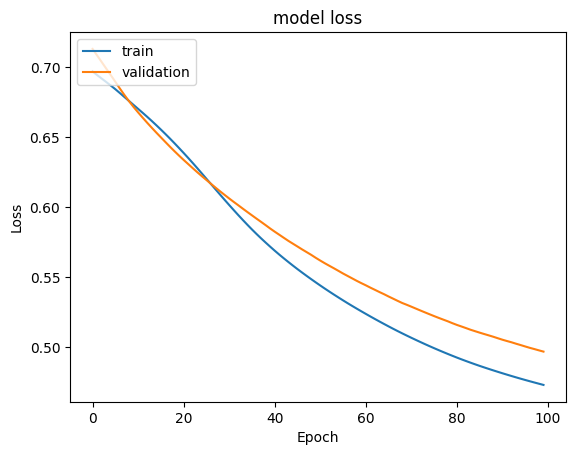

```python
#Plotting Train Loss vs Validation Loss
plt.plot(history_3.history['loss'])
plt.plot(history_3.history['val_loss'])
plt.title('Model #3 Loss - SGD Optimizer + Balanced')
plt.ylabel('Loss')
plt.xlabel('Epoch')
plt.legend(['train', 'validation'], loc='upper left')
plt.show()
```

Observations:

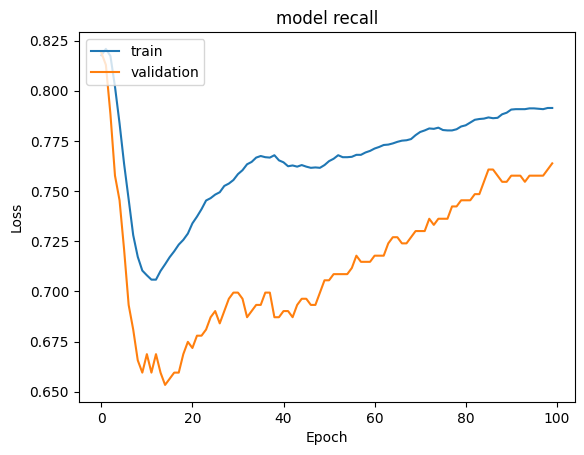

```python
#Plotting Train recall vs Validation recall
plt.plot(history_3.history['recall'])
plt.plot(history_3.history['val_recall'])
plt.title('Model #3 Recall - SGD Optimizer + Balanced')
plt.ylabel('Recall')
plt.xlabel('Epoch')
plt.legend(['train', 'validation'], loc='upper left')
plt.show()
```

Observations:

- Stochastic Gradient Descent with a Balanced data at starting minimized the Recall, however initially, the drop under the first 10 epochs was the most drastic probably as a result of applying the SMOTE to the starting data as only around the 15 epoch the Recall began to favorably increase albeit with noise on the validation set.
- A higher recall means fewer (FN) false negatives!!
- The Recall on the validation set was under but followed pretty close to the training set. --That's impressive!

```python
y_train_pred = model_3.predict(X_train_smote)
#Predicting the results using 0.5 as the threshold
y_train_pred = (y_train_pred > 0.5)
y_train_pred
```

```
319/319 ━━━━━━━━━━━━━━━━━━━━ 1s 2ms/step
```

```
array([[ True],
       [False],
       [False],
       ...,
       [ True],
       [ True],
       [ True]])
```

```python
y_val_pred = model_3.predict(X_val)
#Predicting the results using 0.5 as the threshold
y_val_pred = (y_val_pred > 0.5)
y_val_pred
```

```
50/50 ━━━━━━━━━━━━━━━━━━━━ 0s 1ms/step
```

```
array([[ True],
       [False],
       [False],
       ...,
       [False],
       [ True],
       [ True]])
```

```python
model_name = "NN with SMOTE & SGD"

train_metric_df.loc[model_name] = recall_score(y_train_smote,y_train_pred)
valid_metric_df.loc[model_name] = recall_score(y_val,y_val_pred)
```

**Classification report**

```python
cr=classification_report(y_train_smote,y_train_pred)
print(cr)
```

```
              precision    recall  f1-score   support

           0       0.78      0.76      0.77      5096
           1       0.77      0.79      0.78      5096

    accuracy                           0.78     10192
   macro avg       0.78      0.78      0.77     10192
weighted avg       0.78      0.78      0.77     10192
```

```python
cr=classification_report(y_val,y_val_pred) ## Complete the code to check the model's performance on the validation set
print(cr)
```

```
              precision    recall  f1-score   support

           0       0.92      0.74      0.82      1274
           1       0.42      0.76      0.55       326

    accuracy                           0.74      1600
   macro avg       0.67      0.75      0.68      1600
weighted avg       0.82      0.74      0.76      1600
```

**Confusion matrix**

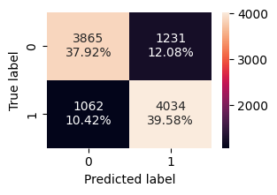

```python
#Calculating the confusion matrix
make_confusion_matrix(y_train_smote, y_train_pred)
```

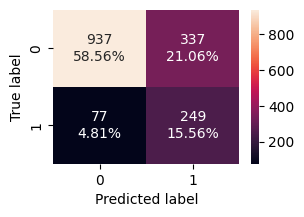

```python
#Calculating the confusion matrix

make_confusion_matrix(y_val,y_val_pred) ## Complete the code to check the model's performance on the validation set
```

Observations:

- Predicted True Positives (TP) successfully increased.
- Predicted False Negatives (FN) successfully decreased significantly with SMOTE balanced or a more uniformed starting data.
- Recall measures how many of the actual positive cases were correctly predicted, and false negatives represent the cases the model missed (failed to predict as positive). A higher recall means fewer false negatives.

### (4) Neural Network with Balanced Data (by applying SMOTE) and Adam Optimizer - - Model Performance Improvement

Let's build a model with the balanced dataset

```python
backend.clear_session()
#Fixing the seed for random number generators so that we can ensure we receive the same output everytime
np.random.seed(2)
random.seed(2)
tf.random.set_seed(2)
```

```python
# Initializing the model
model_4 = Sequential()

# Adding an input layer with 64 neurons and 'relu' as the activation function
model_4.add(Dense(64, activation='relu', input_dim=X_train_smote.shape[1]))

# Adding a hidden layer with 32 neurons and 'relu' as the activation function
model_4.add(Dense(32, activation='relu'))

# Adding another hidden layer with 16 neurons and 'relu' as the activation function
model_4.add(Dense(16, activation='relu'))

# Adding the output layer with 1 neuron and 'sigmoid' as the activation function
model_4.add(Dense(1, activation='sigmoid'))
```

```python
# Use Adam as the optimizer.
optimizer = tf.keras.optimizers.Adam()

# Uncomment one of the following lines to define the metric to be used
# metric = 'accuracy'
metric = keras.metrics.Recall() # TP/(TP+FN) therefore we want an increase of TPs and a decrease of FNs
# metric = keras.metrics.Precision()
# metric = keras.metrics.F1Score()
```

```python
# Complete the code to compile the model with binary cross entropy as loss function and recall as the metric
model_4.compile(loss='binary_crossentropy',optimizer=optimizer,metrics=[metric])
```

```python
model_4.summary()
```

```
Model: "sequential"
```

```
┏━━━━━━━━━━━━━━━━━━━━━━━━━━━━━━━━━━━━━━┳━━━━━━━━━━━━━━━━━━━━━━━━━━━━━┳━━━━━━━━━━━━━━━━━┓
┃ Layer (type)                         ┃ Output Shape                ┃         Param # ┃
┡━━━━━━━━━━━━━━━━━━━━━━━━━━━━━━━━━━━━━━╇━━━━━━━━━━━━━━━━━━━━━━━━━━━━━╇━━━━━━━━━━━━━━━━━┩
│ dense (Dense)                        │ (None, 64)                  │             768 │
├──────────────────────────────────────┼─────────────────────────────┼─────────────────┤
│ dense_1 (Dense)                      │ (None, 32)                  │           2,080 │
├──────────────────────────────────────┼─────────────────────────────┼─────────────────┤
│ dense_2 (Dense)                      │ (None, 16)                  │             528 │
├──────────────────────────────────────┼─────────────────────────────┼─────────────────┤
│ dense_3 (Dense)                      │ (None, 1)                   │              17 │
└──────────────────────────────────────┴─────────────────────────────┴─────────────────┘
```

```
 Total params: 3,393 (13.25 KB)
```

```
 Trainable params: 3,393 (13.25 KB)
```

```
 Non-trainable params: 0 (0.00 B)
```

```python
# Fitting the ANN SMOTE and Adam Optimizer
history_4 = model_4.fit(
    X_train_smote, y_train_smote,
    batch_size=32,  # You can specify the batch size, e.g., 32
    epochs=100,     # You can specify the number of epochs, e.g., 100
    verbose=1,
    validation_data=(X_val, y_val)
)
```

```
319/319 ━━━━━━━━━━━━━━━━━━━━ 4s 7ms/step - loss: 0.5842 - recall: 0.7138 - val_loss: 0.5235 - val_recall: 0.7883
319/319 ━━━━━━━━━━━━━━━━━━━━ 1s 2ms/step - loss: 0.4544 - recall: 0.7830 - val_loss: 0.5017 - val_recall: 0.7669
319/319 ━━━━━━━━━━━━━━━━━━━━ 1s 2ms/step - loss: 0.4337 - recall: 0.7951 - val_loss: 0.4945 - val_recall: 0.7485
319/319 ━━━━━━━━━━━━━━━━━━━━ 1s 2ms/step - loss: 0.4217 - recall: 0.8005 - val_loss: 0.4897 - val_recall: 0.7423
319/319 ━━━━━━━━━━━━━━━━━━━━ 1s 2ms/step - loss: 0.4119 - recall: 0.8077 - val_loss: 0.4895 - val_recall: 0.7362
319/319 ━━━━━━━━━━━━━━━━━━━━ 1s 2ms/step - loss: 0.4030 - recall: 0.8118 - val_loss: 0.4897 - val_recall: 0.7270
319/319 ━━━━━━━━━━━━━━━━━━━━ 1s 2ms/step - loss: 0.3951 - recall: 0.8175 - val_loss: 0.4876 - val_recall: 0.7270
319/319 ━━━━━━━━━━━━━━━━━━━━ 1s 2ms/step - loss: 0.3878 - recall: 0.8214 - val_loss: 0.4920 - val_recall: 0.7270
319/319 ━━━━━━━━━━━━━━━━━━━━ 1s 2ms/step - loss: 0.3807 - recall: 0.8279 - val_loss: 0.4932 - val_recall: 0.7209
319/319 ━━━━━━━━━━━━━━━━━━━━ 1s 2ms/step - loss: 0.3737 - recall: 0.8303 - val_loss: 0.4933 - val_recall: 0.7178
319/319 ━━━━━━━━━━━━━━━━━━━━ 1s 2ms/step - loss: 0.3674 - recall: 0.8363 - val_loss: 0.4967 - val_recall: 0.7270
319/319 ━━━━━━━━━━━━━━━━━━━━ 1s 2ms/step - loss: 0.3608 - recall: 0.8413 - val_loss: 0.4998 - val_recall: 0.7239
319/319 ━━━━━━━━━━━━━━━━━━━━ 1s 2ms/step - loss: 0.3542 - recall: 0.8467 - val_loss: 0.4977 - val_recall: 0.7331
319/319 ━━━━━━━━━━━━━━━━━━━━ 1s 2ms/step - loss: 0.3482 - recall: 0.8521 - val_loss: 0.5016 - val_recall: 0.7362
319/319 ━━━━━━━━━━━━━━━━━━━━ 1s 2ms/step - loss: 0.3419 - recall: 0.8551 - val_loss: 0.5054 - val_recall: 0.7270
319/319 ━━━━━━━━━━━━━━━━━━━━ 1s 2ms/step - loss: 0.3363 - recall: 0.8611 - val_loss: 0.5058 - val_recall: 0.7209
319/319 ━━━━━━━━━━━━━━━━━━━━ 1s 2ms/step - loss: 0.3302 - recall: 0.8618 - val_loss: 0.5090 - val_recall: 0.7178
319/319 ━━━━━━━━━━━━━━━━━━━━ 1s 2ms/step - loss: 0.3247 - recall: 0.8649 - val_loss: 0.5132 - val_recall: 0.7117
319/319 ━━━━━━━━━━━━━━━━━━━━ 1s 2ms/step - loss: 0.3195 - recall: 0.8672 - val_loss: 0.5183 - val_recall: 0.7209
319/319 ━━━━━━━━━━━━━━━━━━━━ 1s 2ms/step - loss: 0.3147 - recall: 0.8738 - val_loss: 0.5218 - val_recall: 0.7025
319/319 ━━━━━━━━━━━━━━━━━━━━ 1s 2ms/step - loss: 0.3091 - recall: 0.8774 - val_loss: 0.5291 - val_recall: 0.7147
319/319 ━━━━━━━━━━━━━━━━━━━━ 1s 2ms/step - loss: 0.3040 - recall: 0.8837 - val_loss: 0.5311 - val_recall: 0.7147
319/319 ━━━━━━━━━━━━━━━━━━━━ 1s 2ms/step - loss: 0.2992 - recall: 0.8850 - val_loss: 0.5424 - val_recall: 0.7086
319/319 ━━━━━━━━━━━━━━━━━━━━ 1s 2ms/step - loss: 0.2940 - recall: 0.8867 - val_loss: 0.5439 - val_recall: 0.7117
319/319 ━━━━━━━━━━━━━━━━━━━━ 1s 2ms/step - loss: 0.2893 - recall: 0.8881 - val_loss: 0.5519 - val_recall: 0.7025
319/319 ━━━━━━━━━━━━━━━━━━━━ 1s 2ms/step - loss: 0.2848 - recall: 0.8899 - val_loss: 0.5533 - val_recall: 0.6933
319/319 ━━━━━━━━━━━━━━━━━━━━ 1s 2ms/step - loss: 0.2805 - recall: 0.8905 - val_loss: 0.5657 - val_recall: 0.6902
319/319 ━━━━━━━━━━━━━━━━━━━━ 1s 2ms/step - loss: 0.2761 - recall: 0.8916 - val_loss: 0.5655 - val_recall: 0.6810
319/319 ━━━━━━━━━━━━━━━━━━━━ 1s 2ms/step - loss: 0.2716 - recall: 0.8948 - val_loss: 0.5707 - val_recall: 0.6779
319/319 ━━━━━━━━━━━━━━━━━━━━ 1s 2ms/step - loss: 0.2674 - recall: 0.8968 - val_loss: 0.5768 - val_recall: 0.6718
319/319 ━━━━━━━━━━━━━━━━━━━━ 1s 2ms/step - loss: 0.2630 - recall: 0.8988 - val_loss: 0.5814 - val_recall: 0.6656
319/319 ━━━━━━━━━━━━━━━━━━━━ 1s 2ms/step - loss: 0.2600 - recall: 0.9019 - val_loss: 0.5894 - val_recall: 0.6718
319/319 ━━━━━━━━━━━━━━━━━━━━ 1s 2ms/step - loss: 0.2558 - recall: 0.9051 - val_loss: 0.5893 - val_recall: 0.6626
319/319 ━━━━━━━━━━━━━━━━━━━━ 1s 2ms/step - loss: 0.2524 - recall: 0.9072 - val_loss: 0.5944 - val_recall: 0.6595
319/319 ━━━━━━━━━━━━━━━━━━━━ 1s 2ms/step - loss: 0.2488 - recall: 0.9085 - val_loss: 0.6012 - val_recall: 0.6564
319/319 ━━━━━━━━━━━━━━━━━━━━ 1s 2ms/step - loss: 0.2455 - recall: 0.9121 - val_loss: 0.6037 - val_recall: 0.6534
319/319 ━━━━━━━━━━━━━━━━━━━━ 1s 2ms/step - loss: 0.2422 - recall: 0.9135 - val_loss: 0.6038 - val_recall: 0.6564
319/319 ━━━━━━━━━━━━━━━━━━━━ 1s 2ms/step - loss: 0.2388 - recall: 0.9157 - val_loss: 0.6111 - val_recall: 0.6595
319/319 ━━━━━━━━━━━━━━━━━━━━ 1s 2ms/step - loss: 0.2359 - recall: 0.9166 - val_loss: 0.6125 - val_recall: 0.6503
319/319 ━━━━━━━━━━━━━━━━━━━━ 1s 2ms/step - loss: 0.2322 - recall: 0.9191 - val_loss: 0.6149 - val_recall: 0.6472
```

[output cut: 45 more lines]

```
319/319 ━━━━━━━━━━━━━━━━━━━━ 1s 2ms/step - loss: 0.1425 - recall: 0.9529 - val_loss: 0.8739 - val_recall: 0.5890
319/319 ━━━━━━━━━━━━━━━━━━━━ 1s 2ms/step - loss: 0.1403 - recall: 0.9527 - val_loss: 0.8795 - val_recall: 0.5828
319/319 ━━━━━━━━━━━━━━━━━━━━ 1s 2ms/step - loss: 0.1391 - recall: 0.9541 - val_loss: 0.8882 - val_recall: 0.5859
319/319 ━━━━━━━━━━━━━━━━━━━━ 1s 2ms/step - loss: 0.1387 - recall: 0.9564 - val_loss: 0.8825 - val_recall: 0.5767
319/319 ━━━━━━━━━━━━━━━━━━━━ 1s 2ms/step - loss: 0.1379 - recall: 0.9574 - val_loss: 0.8980 - val_recall: 0.5736
319/319 ━━━━━━━━━━━━━━━━━━━━ 1s 2ms/step - loss: 0.1361 - recall: 0.9577 - val_loss: 0.8994 - val_recall: 0.5736
319/319 ━━━━━━━━━━━━━━━━━━━━ 1s 2ms/step - loss: 0.1345 - recall: 0.9576 - val_loss: 0.9040 - val_recall: 0.5736
319/319 ━━━━━━━━━━━━━━━━━━━━ 1s 2ms/step - loss: 0.1337 - recall: 0.9578 - val_loss: 0.9044 - val_recall: 0.5675
319/319 ━━━━━━━━━━━━━━━━━━━━ 1s 2ms/step - loss: 0.1324 - recall: 0.9576 - val_loss: 0.9136 - val_recall: 0.5706
319/319 ━━━━━━━━━━━━━━━━━━━━ 1s 2ms/step - loss: 0.1311 - recall: 0.9596 - val_loss: 0.9065 - val_recall: 0.5583
319/319 ━━━━━━━━━━━━━━━━━━━━ 1s 2ms/step - loss: 0.1299 - recall: 0.9592 - val_loss: 0.9147 - val_recall: 0.5644
319/319 ━━━━━━━━━━━━━━━━━━━━ 1s 2ms/step - loss: 0.1291 - recall: 0.9599 - val_loss: 0.9320 - val_recall: 0.5613
319/319 ━━━━━━━━━━━━━━━━━━━━ 1s 2ms/step - loss: 0.1291 - recall: 0.9603 - val_loss: 0.9371 - val_recall: 0.5675
319/319 ━━━━━━━━━━━━━━━━━━━━ 1s 2ms/step - loss: 0.1274 - recall: 0.9602 - val_loss: 0.9402 - val_recall: 0.5736
319/319 ━━━━━━━━━━━━━━━━━━━━ 1s 2ms/step - loss: 0.1260 - recall: 0.9613 - val_loss: 0.9471 - val_recall: 0.5583
```

**Loss function**

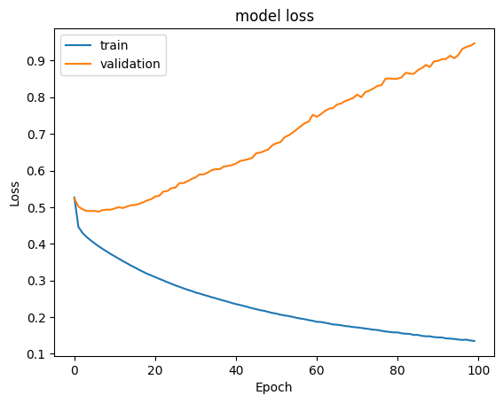

```python
#Plotting Train Loss vs Validation Loss
plt.plot(history_4.history['loss'])
plt.plot(history_4.history['val_loss'])
plt.title('Model #4 Loss - Adam Optimizer + Balanced')
plt.ylabel('Loss')
plt.xlabel('Epoch')
plt.legend(['train', 'validation'], loc='upper left')
plt.show()
```

Observations:

- Interesting loss function here, it decreased in the Training set but increased with the Validation set...why?
- The loss curves do not follow each other.
- This loss is difficult to interpret for me.

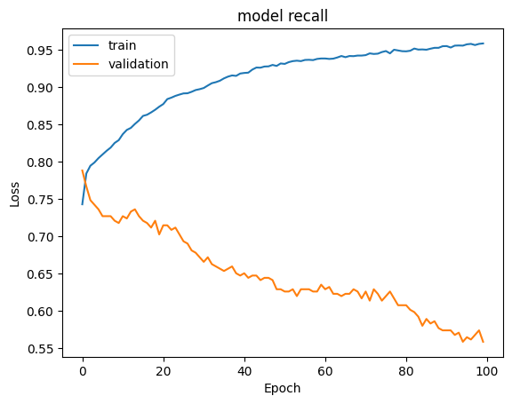

```python
#Plotting Train recall vs Validation recall
plt.plot(history_4.history['recall'])
plt.plot(history_4.history['val_recall'])
plt.title('Model #4 Recall - Adam Optimizer + Balanced')
plt.ylabel('Recall')
plt.xlabel('Epoch')
plt.legend(['train', 'validation'], loc='upper left')
plt.show()
```

Observations:

- What is going on with the Recall? It increased nicely during the training as expected, however with the validation --it was the opposite.

```python
y_train_pred = model_4.predict(X_train_smote)
#Predicting the results using 0.5 as the threshold
y_train_pred = (y_train_pred > 0.5)
y_train_pred
```

```
319/319 ━━━━━━━━━━━━━━━━━━━━ 1s 2ms/step
```

```
array([[ True],
       [False],
       [False],
       ...,
       [ True],
       [ True],
       [ True]])
```

```python
y_val_pred = model_4.predict(X_val)
#Predicting the results using 0.5 as the threshold
y_val_pred = (y_val_pred > 0.5)
y_val_pred
```

```
50/50 ━━━━━━━━━━━━━━━━━━━━ 0s 1ms/step
```

```
array([[False],
       [False],
       [False],
       ...,
       [False],
       [ True],
       [ True]])
```

```python
model_name = "NN with SMOTE & Adam"

train_metric_df.loc[model_name] = recall_score(y_train_smote,y_train_pred)
valid_metric_df.loc[model_name] = recall_score(y_val,y_val_pred)
```

**Classification report**

```python
cr=classification_report(y_train_smote,y_train_pred)
print(cr)
```

```
              precision    recall  f1-score   support

           0       0.97      0.91      0.94      5096
           1       0.91      0.97      0.94      5096

    accuracy                           0.94     10192
   macro avg       0.94      0.94      0.94     10192
weighted avg       0.94      0.94      0.94     10192
```

```python
cr=classification_report(y_val,y_val_pred) ## Complete the code to check the model's performance on the validation set
print(cr)
```

```
              precision    recall  f1-score   support

           0       0.88      0.83      0.85      1274
           1       0.45      0.56      0.50       326

    accuracy                           0.77      1600
   macro avg       0.67      0.69      0.68      1600
weighted avg       0.79      0.77      0.78      1600
```

**Confusion matrix**

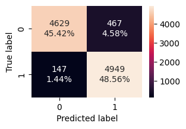

```python
#Calculating the confusion matrix
make_confusion_matrix(y_train_smote, y_train_pred)
```

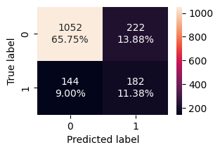

```python
#Calculating the confusion matrix
make_confusion_matrix(y_val,y_val_pred)  ## Complete the code to check the model's performance on the validation set
```

Observations:

- Predicted True Positives (TP) did not increase.
- Predicted False Negatives (FN) did not decrease with SMOTE balanced or a more uniformed starting data and the adaptive optimizer Adam.
- A higher recall means fewer false negatives. A decreasing Recall here with the validation set means the prediction wasn't successful.

### (5) Neural Network with Balanced Data (by applying SMOTE), Adam Optimizer, and Dropout - - Model Performance Improvement

Dropout is a regularization technique used in neural networks to prevent overfitting. Here’s a summary of what it does:

- Randomly “drops” neurons during training: At each training step, a random subset of neurons (and their connections) is “dropped” or temporarily deactivated. This forces the network to learn more robust patterns that don’t rely on specific neurons.
- Prevents overfitting: By randomly dropping neurons, the model cannot over-rely on any one feature or pattern, which helps it generalize better to unseen data, reducing overfitting.
- Improves performance: Dropout encourages the network to learn multiple independent features, improving overall model performance when deployed.

```python
backend.clear_session()
#Fixing the seed for random number generators so that we can ensure we receive the same output everytime
np.random.seed(2)
random.seed(2)
tf.random.set_seed(2)
```

```python
# Initializing the model
model_5 = Sequential()
# Adding input layer with 32 neurons and relu as activation function
model_5.add(Dense(32, activation='relu', input_dim=X_train_smote.shape[1]))
# Adding dropout layer with a dropout rate of 0.2
model_5.add(Dropout(0.2))
# Adding hidden layer with 16 neurons and relu as activation function
model_5.add(Dense(16, activation='relu'))
# Adding dropout layer with a dropout rate of 0.2
model_5.add(Dropout(0.2))
# Adding hidden layer with 8 neurons with relu as activation function
model_5.add(Dense(8, activation='relu'))
# Adding the output layer with 1 neuron and sigmoid activation function
model_5.add(Dense(1, activation='sigmoid'))
```

```python
#Complete the code to use Adam as the optimizer.
optimizer = tf.keras.optimizers.Adam()

# uncomment one of the following lines to define the metric to be used
# metric = 'accuracy'
metric = keras.metrics.Recall()
# metric = keras.metrics.Precision()
# metric = keras.metrics.F1Score()
```

```python
# Complete the code to compile the model with binary cross entropy as loss function and recall as the metric
model_5.compile(loss='binary_crossentropy', optimizer=optimizer, metrics=[metric])
```

```python
model_5.summary()
```

```
Model: "sequential"
```

```
┏━━━━━━━━━━━━━━━━━━━━━━━━━━━━━━━━━━━━━━┳━━━━━━━━━━━━━━━━━━━━━━━━━━━━━┳━━━━━━━━━━━━━━━━━┓
┃ Layer (type)                         ┃ Output Shape                ┃         Param # ┃
┡━━━━━━━━━━━━━━━━━━━━━━━━━━━━━━━━━━━━━━╇━━━━━━━━━━━━━━━━━━━━━━━━━━━━━╇━━━━━━━━━━━━━━━━━┩
│ dense (Dense)                        │ (None, 32)                  │             384 │
├──────────────────────────────────────┼─────────────────────────────┼─────────────────┤
│ dropout (Dropout)                    │ (None, 32)                  │               0 │
├──────────────────────────────────────┼─────────────────────────────┼─────────────────┤
│ dense_1 (Dense)                      │ (None, 16)                  │             528 │
├──────────────────────────────────────┼─────────────────────────────┼─────────────────┤
│ dropout_1 (Dropout)                  │ (None, 16)                  │               0 │
├──────────────────────────────────────┼─────────────────────────────┼─────────────────┤
│ dense_2 (Dense)                      │ (None, 8)                   │             136 │
├──────────────────────────────────────┼─────────────────────────────┼─────────────────┤
│ dense_3 (Dense)                      │ (None, 1)                   │               9 │
└──────────────────────────────────────┴─────────────────────────────┴─────────────────┘
```

```
 Total params: 1,057 (4.13 KB)
```

```
 Trainable params: 1,057 (4.13 KB)
```

```
 Non-trainable params: 0 (0.00 B)
```

```python
history_5 = model_5.fit(
    X_train_smote, y_train_smote,
    batch_size=32,  ## Specify the batch size to use (for example, 32)
    epochs=100,     ## Specify the number of epochs (for example, 100)
    verbose=1,
    validation_data=(X_val, y_val)
)
```

```
319/319 ━━━━━━━━━━━━━━━━━━━━ 5s 8ms/step - loss: 0.6356 - recall: 0.6616 - val_loss: 0.5559 - val_recall: 0.7423
319/319 ━━━━━━━━━━━━━━━━━━━━ 1s 2ms/step - loss: 0.5408 - recall: 0.7611 - val_loss: 0.5131 - val_recall: 0.7761
319/319 ━━━━━━━━━━━━━━━━━━━━ 1s 2ms/step - loss: 0.5135 - recall: 0.7510 - val_loss: 0.4854 - val_recall: 0.7607
319/319 ━━━━━━━━━━━━━━━━━━━━ 1s 2ms/step - loss: 0.4979 - recall: 0.7595 - val_loss: 0.4778 - val_recall: 0.7730
319/319 ━━━━━━━━━━━━━━━━━━━━ 1s 2ms/step - loss: 0.4838 - recall: 0.7709 - val_loss: 0.4710 - val_recall: 0.7393
319/319 ━━━━━━━━━━━━━━━━━━━━ 1s 2ms/step - loss: 0.4804 - recall: 0.7512 - val_loss: 0.4664 - val_recall: 0.7393
319/319 ━━━━━━━━━━━━━━━━━━━━ 1s 2ms/step - loss: 0.4667 - recall: 0.7729 - val_loss: 0.4639 - val_recall: 0.7393
319/319 ━━━━━━━━━━━━━━━━━━━━ 1s 2ms/step - loss: 0.4702 - recall: 0.7658 - val_loss: 0.4614 - val_recall: 0.7362
319/319 ━━━━━━━━━━━━━━━━━━━━ 1s 2ms/step - loss: 0.4559 - recall: 0.7738 - val_loss: 0.4473 - val_recall: 0.7209
319/319 ━━━━━━━━━━━━━━━━━━━━ 1s 2ms/step - loss: 0.4619 - recall: 0.7698 - val_loss: 0.4461 - val_recall: 0.7209
319/319 ━━━━━━━━━━━━━━━━━━━━ 1s 2ms/step - loss: 0.4591 - recall: 0.7791 - val_loss: 0.4450 - val_recall: 0.7055
319/319 ━━━━━━━━━━━━━━━━━━━━ 1s 2ms/step - loss: 0.4527 - recall: 0.7797 - val_loss: 0.4474 - val_recall: 0.7270
319/319 ━━━━━━━━━━━━━━━━━━━━ 1s 2ms/step - loss: 0.4478 - recall: 0.7760 - val_loss: 0.4430 - val_recall: 0.7055
319/319 ━━━━━━━━━━━━━━━━━━━━ 1s 2ms/step - loss: 0.4477 - recall: 0.7866 - val_loss: 0.4468 - val_recall: 0.7178
319/319 ━━━━━━━━━━━━━━━━━━━━ 1s 2ms/step - loss: 0.4450 - recall: 0.7981 - val_loss: 0.4472 - val_recall: 0.7301
319/319 ━━━━━━━━━━━━━━━━━━━━ 1s 2ms/step - loss: 0.4477 - recall: 0.7932 - val_loss: 0.4381 - val_recall: 0.7239
319/319 ━━━━━━━━━━━━━━━━━━━━ 1s 2ms/step - loss: 0.4432 - recall: 0.7932 - val_loss: 0.4393 - val_recall: 0.7117
319/319 ━━━━━━━━━━━━━━━━━━━━ 1s 2ms/step - loss: 0.4390 - recall: 0.7898 - val_loss: 0.4474 - val_recall: 0.7239
319/319 ━━━━━━━━━━━━━━━━━━━━ 1s 2ms/step - loss: 0.4431 - recall: 0.7907 - val_loss: 0.4359 - val_recall: 0.7117
319/319 ━━━━━━━━━━━━━━━━━━━━ 1s 2ms/step - loss: 0.4369 - recall: 0.7942 - val_loss: 0.4472 - val_recall: 0.7055
319/319 ━━━━━━━━━━━━━━━━━━━━ 1s 2ms/step - loss: 0.4371 - recall: 0.7936 - val_loss: 0.4486 - val_recall: 0.7239
319/319 ━━━━━━━━━━━━━━━━━━━━ 1s 2ms/step - loss: 0.4307 - recall: 0.8075 - val_loss: 0.4326 - val_recall: 0.7055
319/319 ━━━━━━━━━━━━━━━━━━━━ 1s 2ms/step - loss: 0.4407 - recall: 0.7917 - val_loss: 0.4397 - val_recall: 0.7025
319/319 ━━━━━━━━━━━━━━━━━━━━ 1s 2ms/step - loss: 0.4280 - recall: 0.8042 - val_loss: 0.4375 - val_recall: 0.7147
319/319 ━━━━━━━━━━━━━━━━━━━━ 1s 2ms/step - loss: 0.4327 - recall: 0.7999 - val_loss: 0.4439 - val_recall: 0.7331
319/319 ━━━━━━━━━━━━━━━━━━━━ 1s 2ms/step - loss: 0.4309 - recall: 0.8083 - val_loss: 0.4430 - val_recall: 0.7362
319/319 ━━━━━━━━━━━━━━━━━━━━ 1s 2ms/step - loss: 0.4340 - recall: 0.8012 - val_loss: 0.4442 - val_recall: 0.7239
319/319 ━━━━━━━━━━━━━━━━━━━━ 1s 2ms/step - loss: 0.4313 - recall: 0.8120 - val_loss: 0.4398 - val_recall: 0.7117
319/319 ━━━━━━━━━━━━━━━━━━━━ 1s 2ms/step - loss: 0.4268 - recall: 0.8121 - val_loss: 0.4351 - val_recall: 0.7270
319/319 ━━━━━━━━━━━━━━━━━━━━ 1s 2ms/step - loss: 0.4294 - recall: 0.8044 - val_loss: 0.4347 - val_recall: 0.7025
319/319 ━━━━━━━━━━━━━━━━━━━━ 1s 2ms/step - loss: 0.4350 - recall: 0.8041 - val_loss: 0.4420 - val_recall: 0.7331
319/319 ━━━━━━━━━━━━━━━━━━━━ 1s 2ms/step - loss: 0.4325 - recall: 0.8029 - val_loss: 0.4321 - val_recall: 0.6994
319/319 ━━━━━━━━━━━━━━━━━━━━ 1s 2ms/step - loss: 0.4344 - recall: 0.7983 - val_loss: 0.4363 - val_recall: 0.7055
319/319 ━━━━━━━━━━━━━━━━━━━━ 1s 2ms/step - loss: 0.4237 - recall: 0.8071 - val_loss: 0.4317 - val_recall: 0.7055
319/319 ━━━━━━━━━━━━━━━━━━━━ 1s 2ms/step - loss: 0.4220 - recall: 0.8083 - val_loss: 0.4350 - val_recall: 0.7025
319/319 ━━━━━━━━━━━━━━━━━━━━ 1s 2ms/step - loss: 0.4218 - recall: 0.8043 - val_loss: 0.4329 - val_recall: 0.7209
319/319 ━━━━━━━━━━━━━━━━━━━━ 1s 2ms/step - loss: 0.4257 - recall: 0.8053 - val_loss: 0.4356 - val_recall: 0.7055
319/319 ━━━━━━━━━━━━━━━━━━━━ 1s 2ms/step - loss: 0.4271 - recall: 0.7996 - val_loss: 0.4367 - val_recall: 0.6994
319/319 ━━━━━━━━━━━━━━━━━━━━ 1s 2ms/step - loss: 0.4284 - recall: 0.7995 - val_loss: 0.4405 - val_recall: 0.7209
319/319 ━━━━━━━━━━━━━━━━━━━━ 1s 2ms/step - loss: 0.4247 - recall: 0.8076 - val_loss: 0.4333 - val_recall: 0.7025
```

[output cut: 45 more lines]

```
319/319 ━━━━━━━━━━━━━━━━━━━━ 1s 2ms/step - loss: 0.4039 - recall: 0.8173 - val_loss: 0.4299 - val_recall: 0.7117
319/319 ━━━━━━━━━━━━━━━━━━━━ 1s 2ms/step - loss: 0.4046 - recall: 0.8164 - val_loss: 0.4259 - val_recall: 0.6994
319/319 ━━━━━━━━━━━━━━━━━━━━ 1s 2ms/step - loss: 0.4039 - recall: 0.8190 - val_loss: 0.4257 - val_recall: 0.7117
319/319 ━━━━━━━━━━━━━━━━━━━━ 1s 2ms/step - loss: 0.3985 - recall: 0.8242 - val_loss: 0.4275 - val_recall: 0.7086
319/319 ━━━━━━━━━━━━━━━━━━━━ 1s 2ms/step - loss: 0.4068 - recall: 0.8210 - val_loss: 0.4248 - val_recall: 0.6994
319/319 ━━━━━━━━━━━━━━━━━━━━ 1s 2ms/step - loss: 0.4032 - recall: 0.8143 - val_loss: 0.4275 - val_recall: 0.7086
319/319 ━━━━━━━━━━━━━━━━━━━━ 1s 2ms/step - loss: 0.4041 - recall: 0.8164 - val_loss: 0.4264 - val_recall: 0.7147
319/319 ━━━━━━━━━━━━━━━━━━━━ 1s 2ms/step - loss: 0.4042 - recall: 0.8136 - val_loss: 0.4280 - val_recall: 0.7117
319/319 ━━━━━━━━━━━━━━━━━━━━ 1s 2ms/step - loss: 0.4059 - recall: 0.8164 - val_loss: 0.4280 - val_recall: 0.7055
319/319 ━━━━━━━━━━━━━━━━━━━━ 1s 2ms/step - loss: 0.4015 - recall: 0.8157 - val_loss: 0.4334 - val_recall: 0.7209
319/319 ━━━━━━━━━━━━━━━━━━━━ 1s 3ms/step - loss: 0.4055 - recall: 0.8259 - val_loss: 0.4306 - val_recall: 0.6963
319/319 ━━━━━━━━━━━━━━━━━━━━ 1s 2ms/step - loss: 0.3965 - recall: 0.8203 - val_loss: 0.4312 - val_recall: 0.7025
319/319 ━━━━━━━━━━━━━━━━━━━━ 1s 2ms/step - loss: 0.4011 - recall: 0.8207 - val_loss: 0.4270 - val_recall: 0.6994
319/319 ━━━━━━━━━━━━━━━━━━━━ 1s 2ms/step - loss: 0.3994 - recall: 0.8248 - val_loss: 0.4304 - val_recall: 0.7117
319/319 ━━━━━━━━━━━━━━━━━━━━ 1s 2ms/step - loss: 0.4004 - recall: 0.8224 - val_loss: 0.4295 - val_recall: 0.6994
```

**Loss function**

[figure not shown]

```python
#Plotting Train Loss vs Validation Loss
plt.plot(history_5.history['loss'])
plt.plot(history_5.history['val_loss'])
plt.title('Model #5 Loss - Adam Opt + Balanced + Dropout')
plt.ylabel('Loss')
plt.xlabel('Epoch')
plt.legend(['train', 'validation'], loc='upper left')
plt.show()
```

Observations:

- Outstanding loss curve for both the Training and Validation sets.

[figure not shown]

```python
#Plotting Train recall vs Validation recall
plt.plot(history_5.history['recall'])
plt.plot(history_5.history['val_recall'])
plt.title('Model #5 Recall - Adam Opt + Balanced + Dropout')
plt.ylabel('Recall')
plt.xlabel('Epoch')
plt.legend(['train', 'validation'], loc='upper left')
plt.show()
```

Observations:

- Recall does not look that great with the validation set.
- Adam optimizer with a Balanced data at starting and Droping some Neurons to improve the learning owith the training set was successful. However it minimized the Recall on the validation set again! Not good!
- A higher recall means fewer (FN) false negatives with the Training set!!
- The Recall on the validation set was poor and noisy.

```python
y_train_pred = model_5.predict(X_train_smote)
#Predicting the results using 0.5 as the threshold
y_train_pred = (y_train_pred > 0.5)
y_train_pred
```

```
319/319 ━━━━━━━━━━━━━━━━━━━━ 1s 2ms/step
```

```
array([[ True],
       [False],
       [False],
       ...,
       [ True],
       [ True],
       [ True]])
```

```python
y_val_pred = model_5.predict(X_val)
#Predicting the results using 0.5 as the threshold
y_val_pred = (y_val_pred > 0.5)
y_val_pred
```

```
50/50 ━━━━━━━━━━━━━━━━━━━━ 0s 1ms/step
```

```
array([[ True],
       [False],
       [False],
       ...,
       [False],
       [ True],
       [ True]])
```

```python
model_name = "NN with SMOTE,Adam & Dropout"

train_metric_df.loc[model_name] = recall_score(y_train_smote,y_train_pred)
valid_metric_df.loc[model_name] = recall_score(y_val,y_val_pred)
```

**Classification report**

```python
cr=classification_report(y_train_smote,y_train_pred)
print(cr)
```

```
              precision    recall  f1-score   support

           0       0.84      0.84      0.84      5096
           1       0.84      0.84      0.84      5096

    accuracy                           0.84     10192
   macro avg       0.84      0.84      0.84     10192
weighted avg       0.84      0.84      0.84     10192
```

```python
#classification report
cr=classification_report(y_val,y_val_pred)  ## Complete the code to check the model's performance on the validation set
print(cr)
```

```
              precision    recall  f1-score   support

           0       0.92      0.83      0.87      1274
           1       0.52      0.70      0.60       326

    accuracy                           0.81      1600
   macro avg       0.72      0.77      0.73      1600
weighted avg       0.83      0.81      0.82      1600
```

**Confusion matrix**

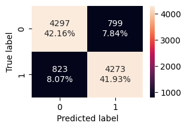

```python
#Calculating the confusion matrix
make_confusion_matrix(y_train_smote, y_train_pred)
```

```python
#Calculating the confusion matrix
make_confusion_matrix(y_val,y_val_pred)  ## Complete the code to check the model's performance on the validation set
```

[output not shown]

Observations:

- A lower (FN) false negatives with the Validation set!!
- Recall was decreased overall.
- Training set look optimistically agreeable as a valid approach.
- However the Validation set proved us wrong.

## Model Performance Comparison and Final Model Selection --------------- Section

```python
print("\nTraining performance comparison:")
train_metric_df
```

```
Training performance comparison
```

|  | recall |
| --- | --- |
| Neutral Network with SGD | 0.325920 |
| NN with Adam | 0.551380 |
| NN with Adam & Dropout | 0.605061 |
| NN with SMOTE & SGD | 0.791601 |
| NN with SMOTE & Adam | 0.971154 |
| NN with SMOTE,Adam & Dropout | 0.838501 |

Observations:

```python
print("\nValidation set performance comparison:")
valid_metric_df
```

```
Validation set performance comparison
```

|  | recall |
| --- | --- |
| Neutral Network with SGD | 0.291411 |
| NN with Adam | 0.441718 |
| NN with Adam & Dropout | 0.441718 |
| NN with SMOTE & SGD | 0.763804 |
| NN with SMOTE & Adam | 0.558282 |
| NN with SMOTE,Adam & Dropout | 0.699387 |

Observations:

```python
train_metric_df - valid_metric_df # Delta between training and validation Recall metric.
```

|  | recall |
| --- | --- |
| Neutral Network with SGD | 0.034509 |
| NN with Adam | 0.109663 |
| NN with Adam & Dropout | 0.163344 |
| NN with SMOTE & SGD | 0.027798 |
| NN with SMOTE & Adam | 0.412872 |
| NN with SMOTE,Adam & Dropout | 0.139114 |

Observations:

- The smallest Recall Delta between the training and validation predictions is also with Model 3 SMOTE + SGD at 0.0277</font>

```python
print("Best NN Model is Model #3 NN + Balanced Data + SGD Optimizer")
y_test_pred = model_3.predict(X_test)    ## Complete the code to specify the best model "Model_0"
y_test_pred = (y_test_pred > 0.5)
print(y_test_pred)
```

```
63/63 ━━━━━━━━━━━━━━━━━━━━ 0s 2ms/step
[[False]
 [False]
 [False]
 ...
 [ True]
 [False]
 [False]]
```

```python
# Classification Report Metrics on Unseen Data.
print("\nClassification Report Metrics on Unseen Data: \n")
cr=classification_report(y_test,y_test_pred)
print(cr)
```

```
              precision    recall  f1-score   support

           0       0.93      0.74      0.82      1593
           1       0.43      0.77      0.55       407

    accuracy                           0.75      2000
   macro avg       0.68      0.76      0.69      2000
weighted avg       0.83      0.75      0.77      2000
```

A final Verification - Using the "winning NN model" predictions against the Test dataset: ... Drum Roll please ... ;-)

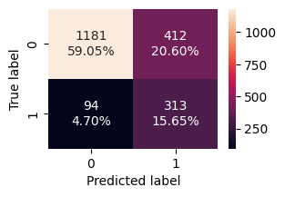

```python
#Calculating the confusion matrix
make_confusion_matrix(y_test,y_test_pred)
```

**Observations:**

## Actionable Insights, Engineering and Business Recommendations ------------------------- Section

Business Recommendations:

- Use Model #3 A Neural Network with Balanced Data and SDG Optimizer to predict Customers likely to depart and exit the bank without saying proper goodbyes nor hugs. But seriously, this model was tested as as the best model to anticipate exits.
- Since most of the Customers if not all are based in Europe, the EU AI Act is required and must be followed.
- Once Corrective Actions are put in place, the model should be re-tested and reverified for efficiency in predicting Customer behavious that affect the bank. This should be done regularly as the data is likely to constantly grow.
- Engineering needs to provide with a User Acceptance Plan to ensure all business units can properly use the predictions properly and all Use Cases are well understood before going to production.
- IT must ensure data recovery after introducing the model into production.
- A Program Manager should capture all the recommendations from this report shown elsewhere to ensure a proper deployment, a cost analysis and the very importan resource allocations of computing resources.
- HR should be invited to review recommendations and insides from this report as they can provide invaluable help in assesing impact to current employees handling sensitive information.
- The bank should prioritize gender diversity initiatives with its vendors and coordinate all marketing similarly in its advertizing strategies, truth in lending, fairness and economic access to create a more balanced and inclusive clientele which can ultimately benefit the company's performance.
- Customer Support should analyze customer exits as they are likely to have experienced unfavorable transactions or help while trying to resolve issues.
- A Root Cause Corrective Action Committe made up of multiple function should review periodically all recommendations and test preventative actions to limit and decrease Customer exits.
- Training and Employee Development should consider offering upskilling or reskilling programs to preperly understand predictive models business process changes, current shortcomings and data impacts to increase business adaptation to these tools as this report recommends.

Engineering Recommendations:

1. Release to a staging environment for functional acceptance testing, end-user acceptance testing, governance and regulatory compliance audits before going to production with the optimized Model #3 with Balanced + SGD Optimizer.
2. Preprocessing New Data: (New Customers without having the the true target values.)
   - Ensure that the new customer data is preprocessed in the same way as the training data. This includes handling missing values, normalizing or scaling features (e.g., using the same StandardScaler instance), and encoding categorical variables whenever applicable.
3. Using the Model for Predictions:
   - Use the trained model to predict outcomes for the new data. Call the predict() method on the model with the preprocessed new data.

     ```
     new_customer_predictions = model.predict(new_customer_data)
     ```

4. Applying Threshold:
   - For binary classification tasks, we typically can apply a threshold to the predicted probabilities to determine class labels. Commonly, a threshold of 0.5 is used, but this can be adjusted based on business needs or the specific context of the problem.

     ```
     new_customer_labels = (new_customer_predictions > 0.5).astype(int)
     ```

5. Interpreting the Predictions:
   - The resulting new_customer_labels can provide with the predicted class for each new customer. For example, in a churn prediction context, a label of 1 could indicate that a customer is likely to churn, while a label of 0 indicates they are likely to stay.
6. Further Evaluation (if possible):
   - When we eventually obtain the true target values for the new customers (e.g., after some time), we can evaluate the performance of our model on this new customer data using metrics like recall, precision, or F1-score as well.
7. Example PseudoCode:

   ```
   - Preprocessing new data
   new_customer_data = preprocess_new_data(raw_new_customer_data)

   - Predicting with the model
   new_customer_predictions = model.predict(new_customer_data)

   - Applying a threshold to get class labels
   new_customer_labels = (new_customer_predictions > 0.5).astype(int)

   - Displaying predictions
   print("Predicted labels for new customers:", new_customer_labels)
   ```

8. Summary:
   - To preprocess the new data in a Staging or Production environments:
   - Use the trained model to predict probabilities,
   - Apply a threshold to classify the outcomes,
   - Interpret these predicted labels for further analysis or action.
   - This process allows making informed decisions regarding new customers, even in the absence of true target values not yet materialized.

Refer to APPENDIX I to determine how to best use this model in production.

# APPENDIX I

**How to use the model to predict outcome with new incoming data?**

When we have trained and validated a neural network (NN) model, and we want to predict values for new data (like new customers) without having the true target values, we follow these steps:

1. Preprocessing New Data:
   - Ensure that the new customer data is preprocessed in the same way as the training data. This includes handling missing values, normalizing or scaling features (e.g., using the same StandardScaler instance), and encoding categorical variables if applicable.
2. Using the Model for Predictions:
   - Use the trained model to predict outcomes for the new data. You can call the predict() method on the model with the preprocessed new data.

```python
# new_customer_predictions = model.predict(new_customer_data)
```

1. Applying Threshold:
   - For binary classification tasks, you will typically apply a threshold to the predicted probabilities to determine class labels. Commonly, a threshold of 0.5 is used, but this can be adjusted based on business needs or the specific context of the problem.

```python
# new_customer_labels = (new_customer_predictions > 0.5).astype(int)
```

1. Interpreting the Predictions:
   - The resulting new_customer_labels will provide you with the predicted class for each new customer. For example, in a churn prediction context, a label of 1 could indicate that a customer is likely to churn, while a label of 0 indicates they are likely to stay.
2. Further Evaluation (if possible):
   - If you eventually obtain the true target values for the new customers (e.g., after some time), you can evaluate the performance of your model on this new data using metrics like recall, precision, or F1-score.

Example Code:

```python
# Preprocessing new data
new_customer_data = preprocess_new_data(raw_new_customer_data)  # Apply necessary preprocessing steps

# Predicting with the model
new_customer_predictions = model.predict(new_customer_data)

# Applying a threshold to get class labels
new_customer_labels = (new_customer_predictions > 0.5).astype(int)

# Displaying predictions
print("Predicted labels for new customers:", new_customer_labels)
```

Summary:

We preprocess the new data, use the trained model to predict probabilities, apply a threshold to classify the outcomes, and then interpret these predicted labels for further analysis or action. This process allows making informed decisions regarding customers, even in the absence of true target values not yet materialized.

# NICE COLORS REFERENCE

### **Browns:**

# APPENDIX II

Building an Artificial Neural Network (ANN)

1. Define the Problem and Architecture Problem: Clearly understand the task (classification, regression, etc.) and the input/output data. Architecture: Choose the number of layers, neurons per layer, and activation functions. Consider factors like complexity and computational resources.
2. Initialize Weights and Biases Random initialization: Assign random values to the weights and biases. Common methods include Xavier initialization or He initialization.
3. Forward Propagation Input layer: Feed the input data to the network. Hidden layers: Calculate the weighted sum of inputs and biases for each neuron, then apply the activation function. Output layer: Compute the final output using the same process.
4. Calculate the Loss Loss function: Choose a suitable loss function based on the problem (e.g., mean squared error for regression, cross-entropy for classification). Compute loss: Calculate the difference between the predicted output and the actual target.
5. Backpropagation Chain rule: Use the chain rule to calculate the gradients of the loss with respect to the weights and biases. Update weights and biases: Adjust the weights and biases in the direction that minimizes the loss.
6. Optimization Optimizer: Select an optimization algorithm (e.g., gradient descent, Adam, RMSprop) to update the weights and biases efficiently. Learning rate: Set the learning rate to control the step size during updates.
7. Training Epochs: Iterate through the entire dataset multiple times (epochs). Mini-batches: Divide the dataset into smaller batches to reduce computational cost and improve generalization. Forward pass, loss calculation, backpropagation, and optimization: Repeat these steps for each mini-batch.
8. Evaluation Validation set: Use a separate validation set to assess the model's performance during training. Metrics: Choose appropriate metrics (e.g., accuracy, precision, recall, F1-score) based on the problem. Overfitting: Monitor for overfitting (when the model performs well on the training set but poorly on the validation set). Example: Building a Multi-Layer Perceptron (MLP) for Image Classification import tensorflow as tf